# Prob 4, CP 1: Um problema pequeno

Utilizando uma amostra de dados da atividade global do github, vamos analisar o comportamento de edição dos usuários em relação à edição de arquivos durante a semana. Os dados brutos contém a contagem de quantas pessoas editaram arquivos com cada extensão de arquivo em cada dia de 2016 e 2017 no github. Para nossa análise vamos focar nas linguagens Python e JavaScript (extensões py e js).

```r
dados = read_csv(here("github.csv")) %>%
  filter(file_extension %in% c("js", "py"))
dados$language <- ifelse(dados$file_extension == "js", "JavaScript",
                 ifelse(dados$file_extension == "py", "Python", "Other"))
# Função que, dado um dia da semana, retorna se ele participa do final de semana ou não.
is_weekend = function(dia) {
 anw = ifelse(dia == "sexta", TRUE,
              ifelse(dia == "sábado", TRUE,
                     ifelse(dia == "domingo", TRUE, FALSE)))

 return(anw)
}
dados = dados %>% mutate(full_date = paste(month_day, the_month, the_year, sep = '-'))
dados = dados %>% mutate(week_day= weekdays(as.Date(full_date,'%d-%m-%Y')))
dados = dados %>% mutate(weekend = is_weekend(week_day))
```

## Para cada linguagem de programação, há uma diferença significativa na sua popularidade durante a semana e durante o fim de semana? Essa diferença é grande?

A popularidade será medida utilizando a média de usuários que editaram cada tipo de arquivo em cada dia da semana.

```r
sumarios = dados %>%
    group_by(week_day, language) %>%
    summarise(media = mean(users))
sumarios$week_day <- factor(sumarios$week_day, levels=c("segunda-feira", "terça-feira","quarta-feira",
                                                        "quinta-feira", "sexta-feira", "sábado", "domingo"))
```

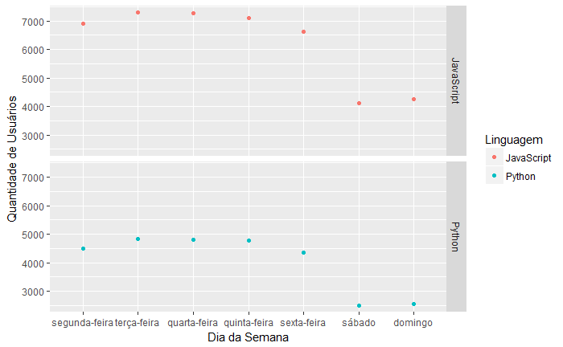

```r
sumarios %>%
  ggplot(aes(x = week_day, y = media, color = language)) +
  geom_point() +
  facet_grid(language ~.) +
  labs(color ="Linguagem", x = "Dia da Semana", y = "Quantidade de Usuários")
```

As duas linguagens possuem um comportamento bem parecido: durante a semana têm uma média alta de edições, e nos finais de semana essa média cai para quase a metade do valor anterior.

## Existe uma diferença significativa entre a popularidade das duas linguagens nos fins de semana?

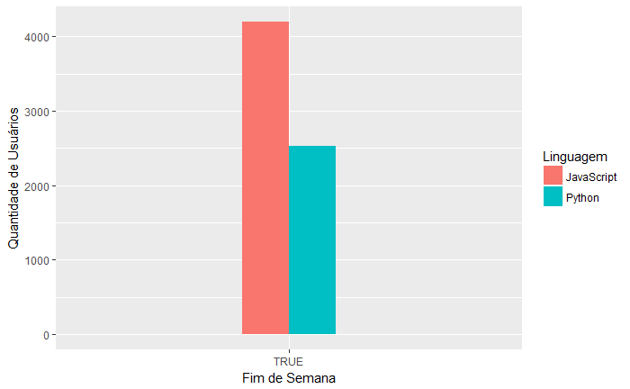

```r
dados %>%
  group_by(weekend, language) %>%
  summarise(media = mean(users)) %>%
  filter(weekend == TRUE) %>%
  ggplot(aes(x = weekend, y = media, fill = language)) +
  geom_bar(stat = "identity", position = "dodge", width = 0.2) +
  labs(fill ="Linguagem", x = "Fim de Semana", y = "Quantidade de Usuários")
```

A popularidade de JavaScript é quase o dobro da popularidade de Python. Isso acontece também (de forma menos acentuada) durante os dias de semana:

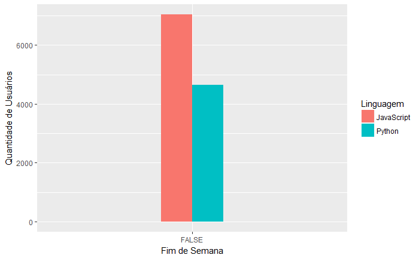

```r
dados %>%
  group_by(weekend, language) %>%
  summarise(media = mean(users)) %>%
  filter(weekend == FALSE) %>%
  ggplot(aes(x = weekend, y = media, fill = language)) +
  geom_bar(stat = "identity", position = "dodge", width = 0.2) +
  labs(fill ="Linguagem", x = "Fim de Semana", y = "Quantidade de Usuários")
```

Portanto essa diferença não é exclusiva dos finais de semana, e sim das linguagens. JavaScript é base para vários frameworks mais robustos que os frameworks Python, e por isso pode haver essa preferência maior.